# Data Exploration with Python

## EXERCISE 1: Reading and accessing data

### Read the survey response data

A *dictionary* is a data structure in Python that can hold key-value pairs, where we can lookup values by their key.

The `pprint` command below prints the dictionary corresponding the the first response.

### Let's define constants for dictionary keys

Before moving on, let's define constants for the keys of this dictionary that will make it a bit easier to use. In our case, the keys are simply the questions from our survey in Week 1.

```python
# This cell is for defining some useful variables for future tasks. Normally, we would prefer to change the column names to
# more memorable ones. However, for the sake of this exercise it is okay.
TIMESTAMP = 'Timestamp'
BACKGROUND_INDUSTRY = 'What main industry have you worked in?'
BACKGROUND_YEARS_PROFESSIONAL = 'How many years professional experience do you have?'
BACKGROUND_YEARS_PROGRAMMING = 'How many years programming experience do you have?'
BACKGROUND_SKILLS = 'What key experience do you have?'
IMPORT_DATA_MANAGEMENT = 'Data management'
IMPORT_STATISTICS = 'Statistics'
IMPORT_VISUALISATION = 'Visualisation'
IMPORT_MACHINE_LEARNING = 'Machine Learning & Data Mining'
IMPORT_SOFTWARE_ENGINEERING = 'Software Engineering'
IMPORT_COMMUNICATION = 'Communication'
GOALS_DEFINITION = 'How would you define Data Science in one sentence?'
GOALS_SKILLS = 'What key skills do you want to learn?'
GOALS_ROLE = 'What kind of role would you like to go into?'
GOALS_INDUSTRY = 'What industry would you like to go into?'
IMPORT_AREAS = [
    IMPORT_DATA_MANAGEMENT,
    IMPORT_STATISTICS,
    IMPORT_VISUALISATION,
    IMPORT_MACHINE_LEARNING,
    IMPORT_SOFTWARE_ENGINEERING,
    IMPORT_COMMUNICATION
]
```

```python
import pprint
import pandas as pd
import numpy as np

import seaborn as sns
import matplotlib.pyplot as plt

from datetime import datetime
from scipy import stats
from collections import Counter, OrderedDict
from functools import reduce
from typing import List, Tuple
```

```python
from google.colab import drive
drive.mount('/content/drive')
```

```python
dataPath = input('Please enter your dataset relative path')
filePath = '/content/drive/MyDrive/' + dataPath
```

```python
# Now, we read our CSV data using pandas
df = pd.read_csv(filePath, encoding="utf-8")

print("Display the first row of the DataFrame as a dictionary (key = column name, value = cell value)")
pprint.pprint(df.iloc[0].to_dict())
```

```
Display the first row of the DataFrame as a dictionary (key = column name, value = cell value)
{'Communication': 5,
 'Data management': 4,
 'How many years professional experience do you have?': '5 years',
 'How many years programming experience do you have?': '0',
 'How would you define Data Science in one sentence?': '✅ Data science is '
                                                       'applicable across '
                                                       'diverse fields.',
 'Machine Learning & Data Mining': 4,
 'Software Engineering': 4,
 'Statistics': 5,
 'Timestamp': '2/11/2026 13:57:51',
 'Visualisation': 4,
 'What industry would you like to go into?': 'Financial Services '
                                             'Authority/Regulators',
 'What key experiences do you have?': 'Visualisation',
 'What key skills do you want to develop?': 'Statistical Analysis, '
                                            'Visualisation, Machine learning, '
                                            'Data mining, Natural Language '
                                            'Processing, Programming',
 'What kind of role would you like to go into?': 'Data Scientist, Analyst, n '
                                                 'our role as a financial '
                                                 'regulatory body, we intend '
                                                 'to develop and enforce '
                                                 'regulations informed by '
                                                 'specific analytical '
                                                 'assessments.',
 'What main industry have you worked in?': 'Indonesia Financial Services and '
                                           'Authority (FSA/OJK) - '
                                           'International Department'}
```

```python
# Display rows 10 to 15 as a list of dictionaries (each row is a dictionary)
print(df.iloc[10:16].to_dict(orient="records"))

# Display rows 10 to 15 as a dictionary of columns (key = column name, value = list of values)
print(df.iloc[10:16].to_dict())

# Display rows 10 to 15 and columns 3 to 4 (index-based selection)
print("Display rows 10 to 15 and columns 3 to 4 (index-based selection)")
print(df.iloc[10:16, 3:5])

# Display rows 10 to 16 and columns listed in IMPORT_AREAS (label-based selection)
print("Display rows 10 to 16 and columns listed in IMPORT_AREAS (label-based selection)")
print(df.loc[10:16, IMPORT_AREAS])
```

```
[{'Timestamp': '2/17/2026 18:05:18', 'What main industry have you worked in?': 'Only interned in marketing ', 'How many years professional experience do you have?': '0', 'How many years programming experience do you have?': '0', 'What key experiences do you have?': 'Information Retrieval, Statistica…
{'Timestamp': {10: '2/17/2026 18:05:18', 11: '2/17/2026 18:18:39', 12: '2/17/2026 18:19:27', 13: '2/17/2026 18:19:40', 14: '2/17/2026 18:20:09', 15: '2/17/2026 18:20:43'}, 'What main industry have you worked in?': {10: 'Only interned in marketing ', 11: 'Information Technology', 12: 'Business analys…
Display rows 10 to 15 and columns 3 to 4 (index-based selection)
   How many years programming experience do you have?  \
10                                                  0
11                                                  5
12                                                1.5
13                                                  2
14                                                  0
15                                                  4

                    What key experiences do you have?
10  Information Retrieval, Statistical Analysis, V...
11  Relational databases, NoSQL, Machine learning,...
12  Relational databases, Statistical Analysis, Vi...
```

[output cut: 21 more lines]

### Accessing data values

```python
# Row 0 corresponds to the first respondent since DataFrames are 0-indexed
# Print the value for 'How many years professional experience do you have?' for the first respondent
print("response:", df.loc[2, BACKGROUND_YEARS_PROFESSIONAL])  # single value (e.g., '5')

# Show the type of the full column (Series)
print("type:", type(df.loc[2, BACKGROUND_YEARS_PROFESSIONAL]))  # pandas.core.series.Series

# Convert the first respondent's value to float (if it's numeric)
print("response (converted):", float(df.loc[2, BACKGROUND_YEARS_PROFESSIONAL]))  # e.g., 5.0

# Show the type of the converted value
print("type:", type(float(df.loc[2, BACKGROUND_YEARS_PROFESSIONAL])))  # <class 'float'>
```

```
response: 1
type: <class 'str'>
response (converted): 1.0
type: <class 'float'>
```

### TODO: What is the third respondent's rating for communication as integer value?

```python
print(int(df.loc[2, IMPORT_COMMUNICATION]))
```

```
5
```

## *STOP PLEASE. THE FOLLOWING IS FOR THE NEXT EXERCISE. THANKS.*

## EXERCISE 2: Frequency distribution and mode

### Counting data

`Counter` from the `collections` module is useful for quickly calculating frequencies.

```python
counts = Counter(df[IMPORT_COMMUNICATION])

print("Distribution of communication importance ratings:")
for rating, count in sorted(counts.items()):
    print(f'{rating}: {count}')
```

```
Distribution of communication importance ratings:
1: 1
2: 1
3: 2
4: 26
5: 41
```

```python
rating_categories = [1, 2, 3, 4, 5]
counts = Counter(df[IMPORT_COMMUNICATION])
distribution = {k: counts.get(k, 0) for k in rating_categories}

print("Distribution of communication importance ratings:")
for rating, count in sorted(distribution.items()):
    print(f'{rating}: {count}')
```

```
Distribution of communication importance ratings:
1: 1
2: 1
3: 2
4: 26
5: 41
```

### TODO: Calculate distribution of background and goal industries

```python
print (f'Distribution of background industries in {BACKGROUND_INDUSTRY}:')

counts = Counter(df[BACKGROUND_INDUSTRY])

for key, value in sorted(counts.items(), reverse=True, key=lambda x: x[1]):
  print(f'{key}: {value}')
```

```
Distribution of background industries in What main industry have you worked in?:
Information Technology: 28
Financial and Insurance Services: 12
Education and Training: 6
Media and Communications: 4
Retail: 2
ScientiIc Research: 2
Student: 2
Utilities: 2
Indonesia Financial Services and Authority (FSA/OJK) - International Department: 1
Manufacturing: 1
never been employed: 1
Only interned in marketing : 1
Business analyst/Consulting: 1
International Relations: 1
medical admin: 1
Medical devices and Pharma: 1
construction business: 1
Export Markets: 1
Fresher UnderGraduate In Comp Science and Engineering: 1
nan: 1
student: 1
```

```python
print (f'Distribution of goal industries in {GOALS_INDUSTRY}:')

counts = Counter(df[GOALS_INDUSTRY])

for key, value in sorted(counts.items(), reverse=True, key=lambda x: x[1]):
  print(f'{key}: {value}')
```

```
Distribution of goal industries in What industry would you like to go into?:
Information Technology: 27
Financial and Insurance Services: 23
Education and Training: 4
Retail: 3
Media and Communications: 3
Scientific Research: 3
Financial Services Authority/Regulators: 1
ART: 1
Consulting/technology: 1
Utilities: 1
Urban Planning: 1
Real Estate: 1
Medical or Scientific Research : 1
Fintech companies : 1
```

### Calculating the mode

```python
mode_values = df[IMPORT_COMMUNICATION].mode()

print("Mode(s) of communication importance ratings:")
print(mode_values.tolist()[0])  # Convert to list to display all modes if multiple
```

```
Mode(s) of communication importance ratings:
5
```

### TODO: Calculate the mode of background and goal industries

```python
# Mode for background industry
print(f'Mode/es of background industries in {BACKGROUND_INDUSTRY}:')
data_bkgr_mode = df[BACKGROUND_INDUSTRY].mode()
print(data_bkgr_mode.to_list()[0])
print('\n')

# Mode for goal industry
print(f'Mode/es of goal industries in {GOALS_INDUSTRY}:')
data_goal_mode = df[GOALS_INDUSTRY].mode()
print(data_goal_mode.to_list()[0])
```

```
Mode/es of background industries in What main industry have you worked in?:
Information Technology


Mode/es of goal industries in What industry would you like to go into?:
Information Technology
```

## *STOP PLEASE. THE FOLLOWING IS FOR THE NEXT EXERCISE. THANKS.*

## EXERCISE 3: Calculating descriptive statistics

### Cleaning float data

Which columns contained ratio data? We need to convert these to numeric types. Let's define another function since we have two ratio variables. Here we replace values that can't be converted with NaN (not a number).

```python
DEFAULT_VALUE = np.nan

def clean(df, column_key, convert_function, default_value):
    for i in range(len(df)):
        val = df.loc[i, column_key]  ## val = df.iloc[i, df.columns.get_loc(column_key)]
        try:
            df.loc[i, column_key] = convert_function(val)
        except (ValueError, TypeError):
            print(f'Replacing {val} with {default_value} in column {column_key} at row {i}')
            df.loc[i, column_key] = default_value

# Usage:
clean(df, BACKGROUND_YEARS_PROFESSIONAL, float, DEFAULT_VALUE)
clean(df, BACKGROUND_YEARS_PROGRAMMING, float, DEFAULT_VALUE)
```

```
Replacing 5 years with nan in column How many years professional experience do you have? at row 0
Replacing 10 years with nan in column How many years professional experience do you have? at row 1
Replacing 3 months with nan in column How many years professional experience do you have? at row 4
Replacing 2 years with nan in column How many years professional experience do you have? at row 16
Replacing 6 months with nan in column How many years professional experience do you have? at row 18
Replacing 2 years + with nan in column How many years professional experience do you have? at row 19
Replacing 1 year with nan in column How many years professional experience do you have? at row 24
Replacing Fresher with nan in column How many years professional experience do you have? at row 26
Replacing Less than 1 year with nan in column How many years professional experience do you have? at row 29
Replacing 6 months with nan in column How many years professional experience do you have? at row 33
Replacing 6 months with nan in column How many years professional experience do you have? at row 35
Replacing Less than 1 year (internship and academic projects) with nan in column How many years professional experience do you have? at row 36
Replacing less than 1 year with nan in column How many years professional experience do you have? at row 69
Replacing i dont have any programming background with nan in column How many years programming experience do you have? at row 1
Replacing 4 years with nan in column How many years programming experience do you have? at row 4
Replacing Not much with nan in column How many years programming experience do you have? at row 6
Replacing less than 1 with nan in column How many years programming experience do you have? at row 8
Replacing 3 years with nan in column How many years programming experience do you have? at row 16
Replacing 1 year with nan in column How many years programming experience do you have? at row 18
Replacing 2 years + with nan in column How many years programming experience do you have? at row 19
Replacing none with nan in column How many years programming experience do you have? at row 24
Replacing 6 months with nan in column How many years programming experience do you have? at row 33
Replacing Little bit with nan in column How many years programming experience do you have? at row 34
Replacing 4+ years of programming experience (academic and training-based). with nan in column How many years programming experience do you have? at row 36
Replacing 2 years with nan in column How many years programming experience do you have? at row 69
```

### Cleaning timestamp data

We may also want to convert timestamp values.

```python
df.loc[0, TIMESTAMP]
```

```
'2/11/2026 13:57:51'
```

```python
FMT = "%m/%d/%Y %H:%M:%S"

def str_to_time(s):
    if isinstance(s, datetime):
        return s
    return datetime.strptime(s, FMT)

clean(df, TIMESTAMP, str_to_time, DEFAULT_VALUE)
```

```python
df.loc[0, TIMESTAMP]
```

```
datetime.datetime(2026, 2, 11, 13, 57, 51)
```

### Statistics with `numpy`

Once the data is converted, we can calculate descriptive statistics. `numpy` includes routines for measures of centrality and dispersion. Below we calculate descriptive statistics for professional and programming experience.

Further detail: http://docs.scipy.org/doc/numpy/reference/routines.statistics.html

```python
import numpy as np

for column_key in [BACKGROUND_YEARS_PROFESSIONAL, BACKGROUND_YEARS_PROGRAMMING]:
    v = df[column_key].astype(float)  # Ensure values are float for calculations

    print(column_key.upper())
    print(f"* Min..Max: {v.min():.2f}..{v.max():.2f}")
    print(f"* Range: {v.max() - v.min():.2f}")
    print(f"* Mean: {v.mean():.2f}")
    print(f"* Standard deviation: {v.std():.2f}")
    print(f"* Median: {v.median():.2f}")

    q1 = v.quantile(0.25)
    print(f"* 25th percentile (Q1): {q1:.2f}")

    q3 = v.quantile(0.75)
    print(f"* 75th percentile (Q3): {q3:.2f}")

    iqr = q3 - q1
    print(f"* IQR: {iqr:.2f}\n")
```

```
HOW MANY YEARS PROFESSIONAL EXPERIENCE DO YOU HAVE?
* Min..Max: 0.00..20.00
* Range: 20.00
* Mean: 3.22
* Standard deviation: 3.95
* Median: 2.00
* 25th percentile (Q1): 1.00
* 75th percentile (Q3): 4.75
* IQR: 3.75

HOW MANY YEARS PROGRAMMING EXPERIENCE DO YOU HAVE?
* Min..Max: 0.00..9.00
* Range: 9.00
* Mean: 2.21
* Standard deviation: 2.14
* Median: 2.00
* 25th percentile (Q1): 0.00
* 75th percentile (Q3): 3.50
* IQR: 3.50
```

### Binning and histograms

`numpy` also provides routines for binning and producing histograms from ratio data.

NOTE RuntimeWarning due to NaN values, which are then ignored in histogram.

```python
v = df[BACKGROUND_YEARS_PROFESSIONAL].dropna().astype(float)  # clean numeric series

freqs, bins = np.histogram(v, bins=7, range=(0, 35))  # frequencies and bin edges

for i, freq in enumerate(freqs):
    bin_str = f'[{int(bins[i])}..{int(bins[i+1])}]'
    print(bin_str, ':', freq)
```

```
[0..5] : 43
[5..10] : 12
[10..15] : 1
[15..20] : 0
[20..25] : 2
[25..30] : 0
[30..35] : 0
```

### TODO: Calculate histogram for programming experience

```python
v = df[BACKGROUND_YEARS_PROGRAMMING].dropna().astype(float)

freqs, bins = np.histogram(v, bins=7, range=(0, 35))

for i, freq in enumerate(freqs):
    bin_str = f'[{int(bins[i])}..{int(bins[i+1])}]'
    print(bin_str, ':', freq)
```

```
[0..5] : 49
[5..10] : 10
[10..15] : 0
[15..20] : 0
[20..25] : 0
[25..30] : 0
[30..35] : 0
```

```python
bin_width = 2 # Chose the binwidth according with the business rules

range = v.max() - v.min()
bin_number = int(range // bin_width)

freqs, bins = np.histogram(v, bins=bin_number, range=(0, 10))

for i, freq in enumerate(freqs):
    bin_str = f'[{int(bins[i])}..{int(bins[i+1])}]'
    print(bin_str, ':', freq)
```

```
[0..2] : 36
[2..5] : 13
[5..7] : 9
[7..10] : 1
```

## *STOP PLEASE. THE FOLLOWING IS FOR THE NEXT EXERCISE. THANKS.*

## EXERCISE 4: Visualisation with matplotlib

### Making a bar chart

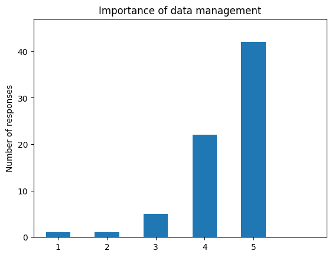

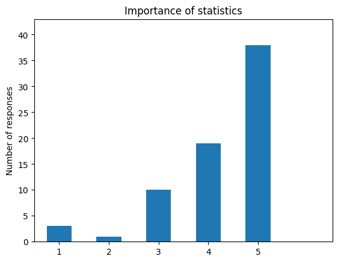

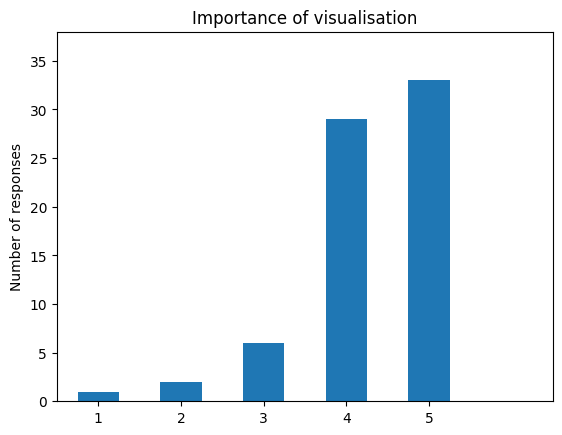

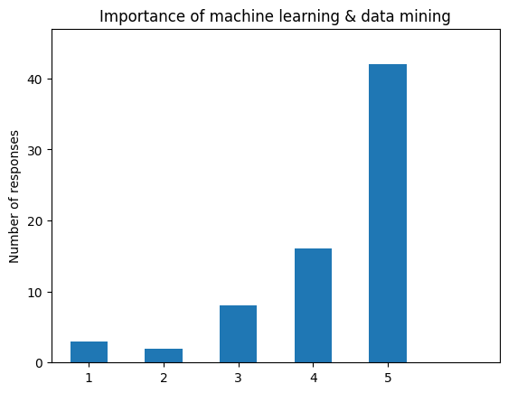

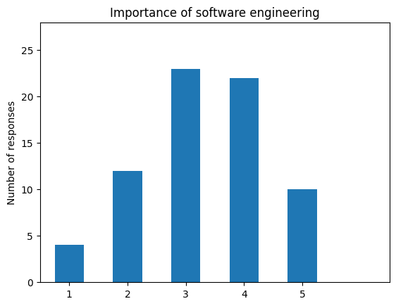

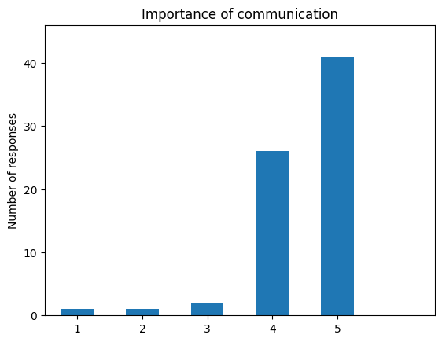

```python
IMPORT_KEYS = ['1', '2', '3', '4', '5']

def make_importance_plot(df, column_key, title):
    counts = Counter(df[column_key].dropna().astype(str))
    d = OrderedDict((k, counts.get(k, 0)) for k in IMPORT_KEYS)
    xs = [i + 0.5 for i, _ in enumerate(IMPORT_KEYS)]
    #We offset the index by 0.5 to center the bars nicely on the x-axis ticks.
    #Without +0.5, bars would start at 0, 1, 2, etc., which can make the labels or bars misaligned visually.
    #With +0.5, bars are centered at 0.5, 1.5, 2.5, ..., which matches the x-axis tick marks labeled as '1', '2', '3', etc.
    plt.bar(xs, d.values(), width=0.5)
    plt.ylabel('Number of responses')
    plt.axis([0, 6, 0, max(d.values()) + 5])
    plt.title(title)
    plt.xticks(xs, IMPORT_KEYS)
    plt.show()

for col in IMPORT_AREAS:
    title = f'Importance of {col.lower()}'
    make_importance_plot(df, col, title)
```

### TODO: Make bar charts of known and future industries

```python
def thresholdCap(common_list: List[Tuple], grouping_category_name: str = 'other', threshold: int = 1) -> List[Tuple]:
    """
    Aggregates elements in a list of tuples that fall below or equal to a specified threshold into a single category.

    Args:
        common_list (List[Tuple]): A list of (label, count) tuples, typically from Counter.most_common(), where the second element is the numeric value to be thresholded.

        grouping_category_name (str): The name of the category to group low-value items into. Defaults to 'other'.

        threshold (int): The value threshold for grouping. Defaults to 1.

    Returns:
        List[Tuple]: A list containing tuples above the threshold and a single tuple representing the sum of those below.
    """
    # Determine upper and lower lists categories to reduce the number of short bars in the plot
    upper_list = list(filter(lambda x: x[1] > threshold, common_list))
    lower_list = list(filter(lambda x: x[1] <= threshold, common_list))

    # Calculate the total count of items below the threshold
    total_under_thresh = reduce(lambda x, y: x + y, (map(lambda x: x[1], lower_list)))

    # Create a single tuple for the lower category
    lower_category = [(grouping_category_name, total_under_thresh)]

    # Add the lower category to the upper list
    upper_list = upper_list + lower_category
    return upper_list

def make_industries_plot(common_list: List[Tuple], title: str) -> None:
    """
    Creates a bar plot visualizing industry frequencies from a list of tuples.

    Args:
        common_list (List[Tuple]): A list of (label, count) tuples to be plotted.

        title (str): The title of the generated plot.

    Returns:
        None: Displays the plot using matplotlib.
    """
    # An efficient way to sort the list of tuples
    values = sorted(common_list, key = lambda x: x[1])

    # Create x values for the plot
    xs = [i + 0.5 for i in np.arange(len(values))]

    # Create the plot
    plt.bar(xs, [val for _, val in values], width=0.5)
    plt.ylabel('Number of responses')
    plt.axis([0, len(values), 0, max([val for _, val in values]) + 5])
    plt.xticks(xs, [name[:50] for name, _ in values], rotation = 45, fontsize = 9, horizontalalignment = 'right')
    plt.title(title)
    plt.show()
```

```python
# We define a threshold to limit the number of individual categories to be plotted
threshold = 1

# Data processing for reported background industries within column BACKGROUND_INDUSTRY
background_industries = df[BACKGROUND_INDUSTRY].copy()
background_industries = background_industries.str.lower()

background_industries.iloc[background_industries.where(background_industries.str.lower() == "student").dropna().index] = 'education and training'

background_industries.dropna(inplace = True)

background_industries = Counter(background_industries).most_common()

background_industries = thresholdCap(background_industries, threshold = threshold)

# Data processing for reported goal industries within column GOAL_INDUSTRY
goal_industries = df[GOALS_INDUSTRY].copy()
goal_industries = goal_industries.str.lower()
goal_industries.dropna(inplace = True)

goal_industries = Counter(goal_industries.dropna().str.lower()).most_common()

goal_industries = thresholdCap(goal_industries, threshold = threshold)
```

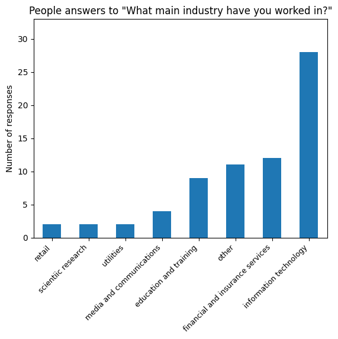

[figure not shown]

```python
collection = [(BACKGROUND_INDUSTRY, background_industries), (GOALS_INDUSTRY, goal_industries)]

for col, answers in collection:
    title = f'People answers to "{col}"'
    make_industries_plot(background_industries, title = title)
```

### Making a histogram

Now let's use the `histogram` from `numpy` above to create a histograms of professional and programming experience.

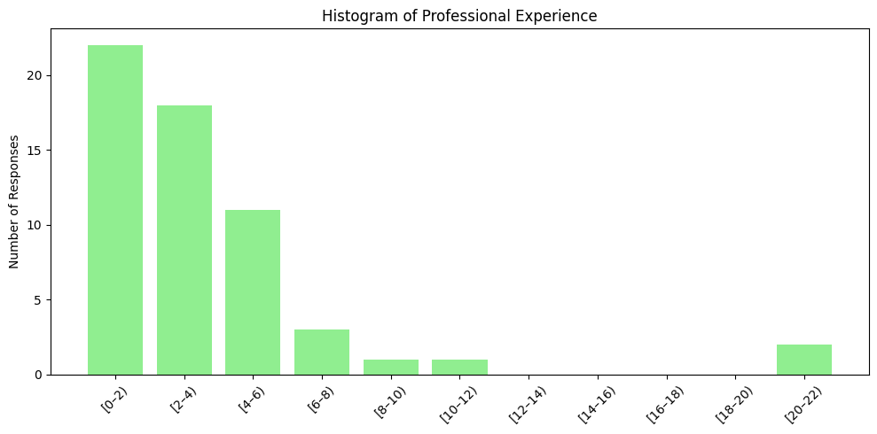

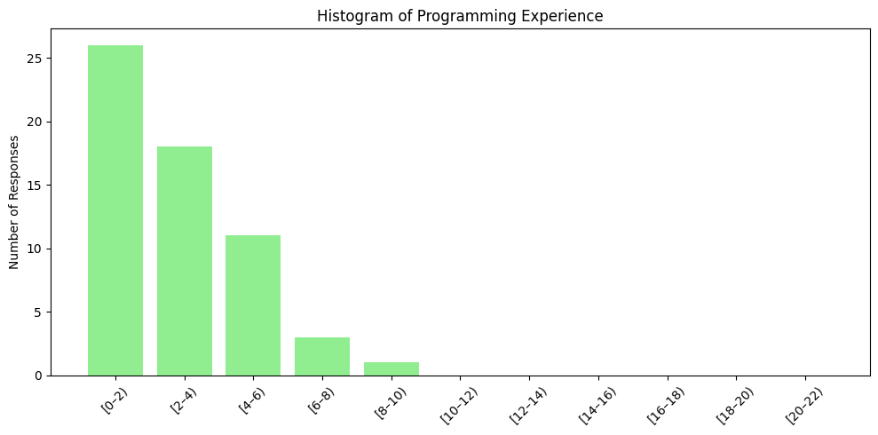

```python
def plot_experience_histogram(data, column_key, title, bin_size=2, range_max=22):
    # Drop missing values
    values = data[column_key].dropna()

    # Compute bins based on bin size
    bins = np.arange(0, range_max + bin_size, bin_size)

    # Get histogram data
    freqs, bin_edges = np.histogram(values, bins=bins)

    # Format bin labels
    bin_labels = [f"[{int(bin_edges[i])}–{int(bin_edges[i+1])})" for i in np.arange(len(freqs))]

    # Plot
    plt.figure(figsize=(10, 5))
    plt.bar(bin_labels, freqs, width=0.8, color='lightgreen')
    plt.xticks(rotation=45)
    plt.ylabel("Number of Responses")
    plt.title(title)
    plt.tight_layout()
    plt.show()

# Example usage:
plot_experience_histogram(df, BACKGROUND_YEARS_PROFESSIONAL, "Histogram of Professional Experience")
plot_experience_histogram(df, BACKGROUND_YEARS_PROGRAMMING, "Histogram of Programming Experience")
```

### Making a scatterplot

Finally, let's make a scatterplot to compare professional and programming experience.

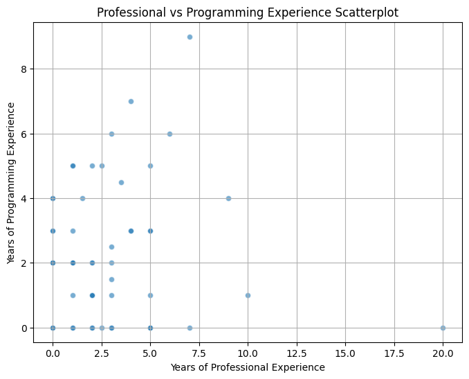

```python
# Drop rows where either column is missing
df_clean = df.dropna(subset=[BACKGROUND_YEARS_PROFESSIONAL, BACKGROUND_YEARS_PROGRAMMING])

plt.figure(figsize=(8,6))
plt.scatter(df_clean[BACKGROUND_YEARS_PROFESSIONAL], df_clean[BACKGROUND_YEARS_PROGRAMMING], alpha=0.6, edgecolors='w')

plt.xlabel('Years of Professional Experience')
plt.ylabel('Years of Programming Experience')
plt.title('Professional vs Programming Experience Scatterplot')
plt.grid(True)
plt.show()
```

## *STOP PLEASE. THE FOLLOWING IS FOR THE NEXT EXERCISE. THANKS.*

## EXERCISE 5: Box plots and correlation

### Visualising distributions with box plots

Mean and standard deviation are not informative for skewed data. `boxplot` is is a good visualisation for viewing and comparing distributions. It also shows outliers, e.g., values greater than `Q3+1.5*IQR` or less than `Q1-1.5*IQR`.

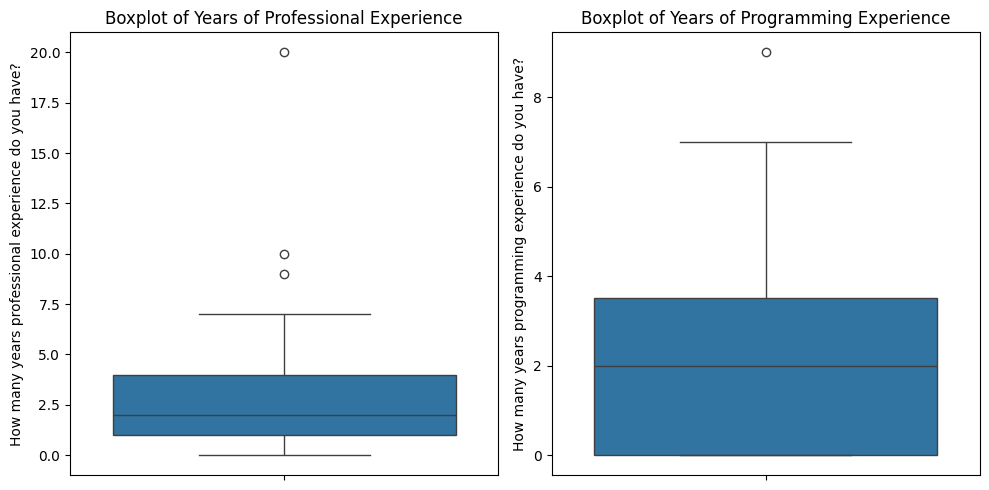

```
Pearson correlation between professional and programming experience: 0.012
```

```python
# Clean data by dropping rows with missing values in the two columns
df_clean = df.dropna(subset=[BACKGROUND_YEARS_PROFESSIONAL, BACKGROUND_YEARS_PROGRAMMING])

# Box plots
plt.figure(figsize=(10,5))

plt.subplot(1, 2, 1)
sns.boxplot(y=df_clean[BACKGROUND_YEARS_PROFESSIONAL])
plt.title('Boxplot of Years of Professional Experience')

plt.subplot(1, 2, 2)
sns.boxplot(y=df_clean[BACKGROUND_YEARS_PROGRAMMING])
plt.title('Boxplot of Years of Programming Experience')

plt.tight_layout()
plt.show()

# Correlation coefficient
corr = df_clean[BACKGROUND_YEARS_PROFESSIONAL].corr(df_clean[BACKGROUND_YEARS_PROGRAMMING])
print(f"Pearson correlation between professional and programming experience: {corr:.3f}")
```

Python code to remove outliers from those two columns in a pandas DataFrame using the IQR method, which is a common and robust approach:

```python
import pandas as pd

def remove_outliers_iqr(df, column):
    Q1 = df[column].quantile(0.25)
    Q3 = df[column].quantile(0.75)
    IQR = Q3 - Q1
    lower_bound = Q1 - 1.5 * IQR
    upper_bound = Q3 + 1.5 * IQR
    # Keep only rows where values are within the bounds
    return df[(df[column] >= lower_bound) & (df[column] <= upper_bound)]

# Remove outliers from both columns step-by-step
df_clean = remove_outliers_iqr(df_clean, BACKGROUND_YEARS_PROFESSIONAL)
df_clean = remove_outliers_iqr(df_clean, BACKGROUND_YEARS_PROGRAMMING)
```

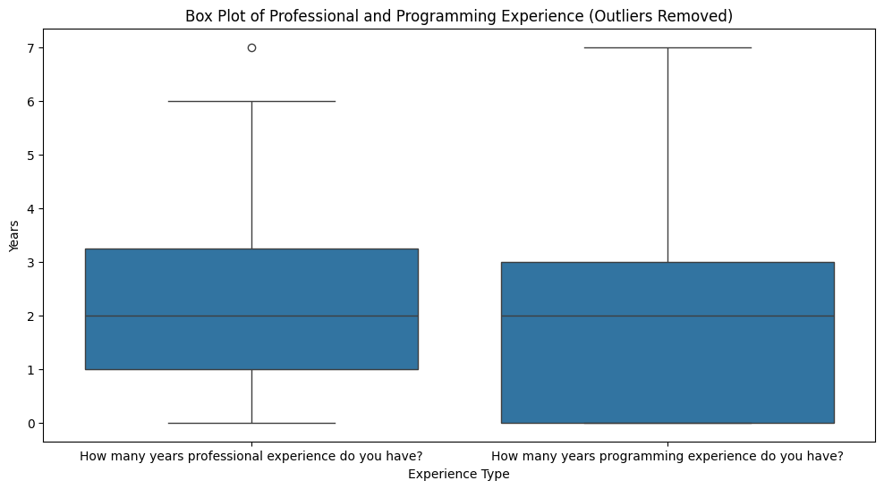

```python
# Melt the dataframe to long format for easier plotting with seaborn
df_melted = df_clean[[BACKGROUND_YEARS_PROFESSIONAL, BACKGROUND_YEARS_PROGRAMMING]].melt(
    var_name='Experience Type',
    value_name='Years'
).dropna()

plt.figure(figsize=(12, 6))
sns.boxplot(x='Experience Type', y='Years', data=df_melted)
plt.title('Box Plot of Professional and Programming Experience (Outliers Removed)')
plt.show()
```

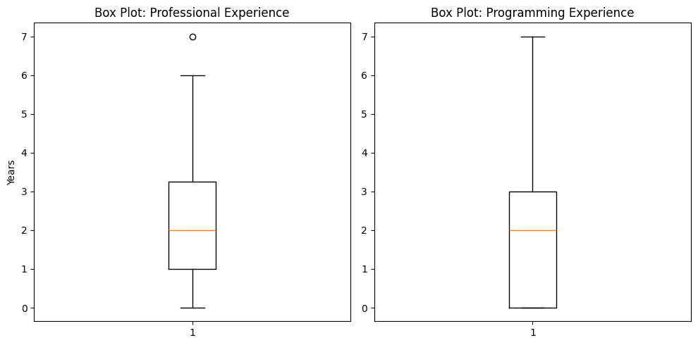

```python
# Assuming df_clean is the DataFrame after outlier removal (from previous step)
plt.figure(figsize=(10, 5))

# Box plot for Professional experience
plt.subplot(1, 2, 1)
plt.boxplot(df_clean[BACKGROUND_YEARS_PROFESSIONAL].dropna())
plt.title('Box Plot: Professional Experience')
plt.ylabel('Years')

# Box plot for Programming experience
plt.subplot(1, 2, 2)
plt.boxplot(df_clean[BACKGROUND_YEARS_PROGRAMMING].dropna())
plt.title('Box Plot: Programming Experience')

plt.tight_layout()
plt.show()
```

### Calculating correlation between two variables

```python
# Drop rows where either value is NaN after conversion
df_clean = df[[BACKGROUND_YEARS_PROFESSIONAL, BACKGROUND_YEARS_PROGRAMMING]].dropna() # Add .copy() to avoid SettingWithCopyWarning

# Convert columns to numeric type (float)
prof = df_clean[BACKGROUND_YEARS_PROFESSIONAL].astype(float).to_numpy()
prog = df_clean[BACKGROUND_YEARS_PROGRAMMING].astype(float).to_numpy()


pearson_corr = stats.pearsonr(prof, prog)
print(f"Pearson (r, p): {pearson_corr}")

spearman_corr = stats.spearmanr(prof, prog)
print(f"Spearman (rho, p): {spearman_corr}")
```

```
Pearson (r, p): PearsonRResult(statistic=np.float64(0.012108311534704503), pvalue=np.float64(0.9300847080488199))
Spearman (rho, p): SignificanceResult(statistic=np.float64(0.041052015077560546), pvalue=np.float64(0.7660218410930486))
```